# Análise Exploratória dos Dados

### Componentes do grupo

- Johanny Santos
- Henrique Benedito
- Matheus Benedito
- Natan Ribeiro
- Saulo Nascimento

### Carregando bibliotecas necessárias para a análise exploratória dos dados

Inicialmente, precisamos carregar as bibliotecas que iremos utilizar durante toda a análise exploratória dos dados.

```r
library(tidyverse)
library(ggplot2)
theme_set(theme_bw())
```

### Definindo o local de trabalho

A pasta base que vamos trabalhar é o repositório baixado do [github](https://github.com/nazareno/reclamacoes-do-gf) do professor Nazareno, da disciplina ‘Metodologia Científica’.

```r
setwd("~/workspace/metodologia/reclamacoes-do-gf")
```

### Definindo tabelas que vamos analisar

- **avaliacoes** -> Avaliações humanas
- **reclamacoes** -> Reclamações avaliadas

```r
avaliacoes <- read_csv("data/3-avaliacao-humana/avaliacoes-20180610.csv")
reclamacoes <- read_csv("data/1-reclamacoes-selecionadas/reclamacoes-avaliadas.csv")
```

### Renomeando colunas da tabela ‘avaliacoes’ para melhor visualização

- A coluna ‘Matricula’ passa a ser ‘avaliador’;
- A coluna ‘ID da reclamação’ passa a ser ‘id’;
- A coluna ‘Grau de insatisfação’ passa a ser ‘insatisfacao’;

```r
avaliacoes <- avaliacoes %>%
              select(avaliador = `Matricula`,
                      id = `ID da reclamação`,
                       insatisfacao = `Grau de insatisfação`)
```

### Inserindo colunas na tabela **reclamacoes**

```r
reclamacoes <- reclamacoes %>% mutate(reclamacao.length = str_length(reclamacao),
                                      titulo.length = str_length(titulo),
                                      numero.de.capslock = str_count(reclamacoes$reclamacao, "\\b[A-Z]{2,}\\b"))
```

### Formato das distribuições dos tamanhos dos títulos e das reclamações

Gráficos de distribuições gerados para o tamanho dos títulos e das reclamações, filtrando-os por órgão (reclamações da ANAC e reclamações do INSS)

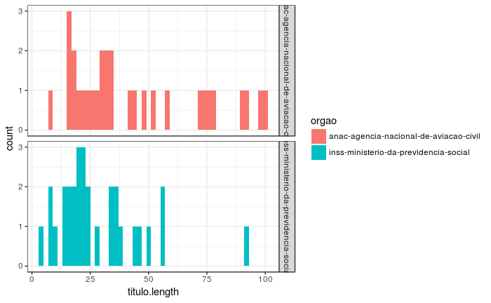

```r
reclamacoes %>%
  filter(complete.cases(.)) %>%
  ggplot(aes(fill = orgao, x = titulo.length), na.rm = TRUE) +
  geom_histogram(binwidth = 2, na.rm = TRUE) +
  facet_grid(orgao ~ .)
```

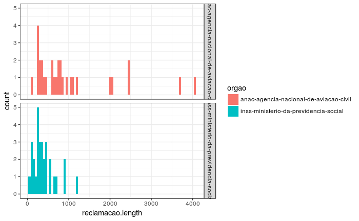

```r
reclamacoes %>%
  filter(complete.cases(.)) %>%
  ggplot(aes(fill = orgao, x = reclamacao.length), na.rm = TRUE) +
  geom_histogram(binwidth = 50, na.rm = TRUE) +
  facet_grid(orgao ~ .)
```

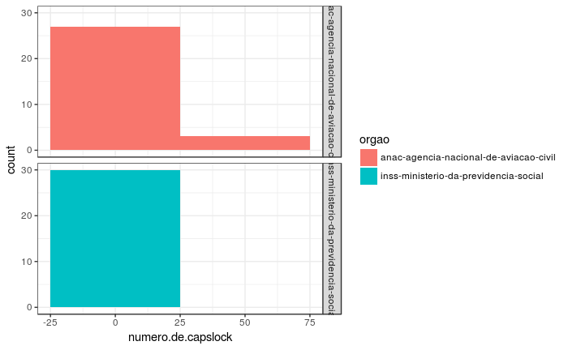

```r
reclamacoes %>%
  filter(complete.cases(.)) %>%
  ggplot(aes(fill = orgao, x = numero.de.capslock), na.rm = TRUE) +
  geom_histogram(binwidth = 50, na.rm = TRUE) +
  facet_grid(orgao ~ .)
```

### Análise das reclamações em cada órgão

De acordo com os gráficos gerados acima, podemos ver que as reclamações do INSS são, em média, menores do que as reclamações da ANAC. Além disso, as reclamações da ANAC possuem um pouco mais de letras com CAPSLOCK com relação às reclamações do INSS.

## *Será que podemos confiar em nossas avaliações humanas?*

### Verificando se alguma avaliação foge do intervalo de valores de 1 a 5

Antes de realizar análises, é preciso verificar se a faixa de valores das avaliações humanas realizadas estão dentro do intervalo pré-definido, onde 1 significa pouco insatisfeito e 5 significa muito insatisfeito.

Como podemos ver na tabela gerada abaixo, todas as avaliações realizadas estão dentro do intervalo pré-definido.

```r
avaliacoes %>%
  filter((insatisfacao %in% 1:5 ))
```

| avaliador | id | insatisfacao |
| --- | --- | --- |
| 113110007 | 2 | 4 |
| 113110007 | 8 | 4 |
| 113110007 | 14 | 1 |
| 113110007 | 20 | 1 |
| 113110007 | 26 | 3 |
| 113110007 | 32 | 1 |
| 113110007 | 38 | 3 |
| 113110007 | 44 | 4 |
| 113110007 | 50 | 1 |
| 113110007 | 56 | 5 |

[output cut: 309 more lines]

### Número de avaliações realizadas por reclamação

Como podemos ver pelo gráfico gerado abaixo, a maioria das reclamações possuem, aproximadamente, 5 avaliações realizadas por reclamação. Poucas reclamações receberam, aproximadamente, 3 avaliações.

No experimento, cada avaliador deveria avaliar 10 reclamações, mas não seriam as mesmas reclamações. Por isso, essa divergência entre o número de avaliações por reclamações.

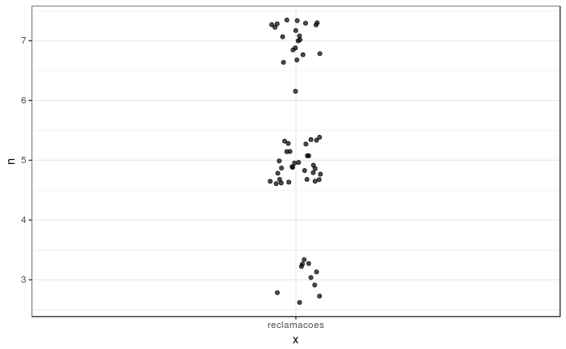

```r
avaliacoes %>%
  group_by(id) %>%
  count() %>%
  ggplot(aes("reclamacoes", n)) +
  geom_jitter(width = .05, alpha = .7)
```

### Número médio de avaliações por reclamação

Confirmando os dados visto no gráfico gerado acima, em média, as reclamações receberam 5 avaliações dos avaliadores. No cálculo, obtivemos uma média de **5.316667** avaliações por reclamação.

```r
avaliacoes %>%
  group_by(id) %>%
  count() %>%
  ungroup() %>%
  summarise(media = mean(n),
            mediana = median(n))
```

| media | mediana |
| --- | --- |
| 5.316667 | 5 |

### Número de revisores por reclamação

Aqui podemos ter uma visão geral do número de avaliações realizadas por reclamação. Temos o ID da reclamação em função do número de avaliações realizadas na reclamação.

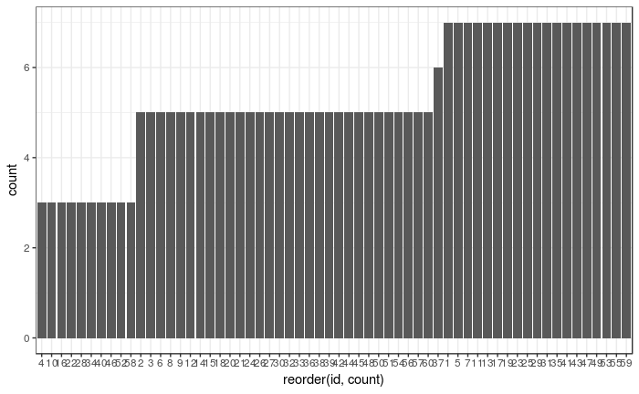

```r
avaliacoes %>% group_by(id) %>%
  summarize(count=n()) %>%
  ggplot(aes(x=reorder(id, count), y=count)) + geom_bar(stat = "identity")
```

### Níveis de discordância X ID da Reclamação

Como podemos analisar no gráfico abaixo, algumas reclamações tiveram uma discordância de até 3 níveis de insatisfação, e a maioria tiveram discordância entre 1 e 2 níveis e poucas não tiveram discordância entre os avaliadores.

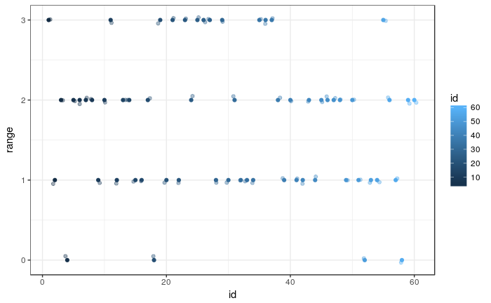

```r
avaliacoes %>% group_by(id) %>%
  summarise(range = max(insatisfacao) - min(insatisfacao),
            mediana = median(insatisfacao)) %>%
  ggplot(aes(x=id, y=range, colour = id)) + geom_point() +
  geom_jitter(height = 0.05, alpha = .4)
```

#### Como foi visto no gráfico anterior, confirmamos na tabela abaixo que a maioria das avaliações tiveram nível de discordância de 1 (21) e 2 (22), e apenas 13 tiveram discordância maior que 2.

```r
avaliacoes %>% group_by(id) %>%
  summarise(range = max(insatisfacao) - min(insatisfacao),
            mediana = median(insatisfacao)) %>%
  group_by(range) %>% count()
```

| range | n |
| --- | --- |
| 0 | 4 |
| 1 | 21 |
| 2 | 22 |
| 3 | 13 |

### Níveis de Discordância X Nível Médio de Insatisfação

```r
avaliacoes %>% group_by(id) %>%
  summarise(range = max(insatisfacao) - min(insatisfacao),
            mediana = median(insatisfacao)) %>%
  ggplot(aes(x=mediana, y=range)) + geom_point() +
  geom_jitter(height = 0.05, alpha = .4)
```

[output not shown]

### Lista de reclamações com discordância maior que 2

```r
avaliacoes %>% group_by(id) %>%
  summarise(range = max(insatisfacao) - min(insatisfacao)) %>%
  filter(range > 2) %>% inner_join(reclamacoes, by = "id") %>% View()
```

### Removendo as reclamações com discordância maior que 2

```r
avaliacoes_filtradas = avaliacoes %>% group_by(id) %>%
  summarise(range = max(insatisfacao) - min(insatisfacao)) %>%
  filter(range < 3) %>% inner_join(reclamacoes, by = "id")
```

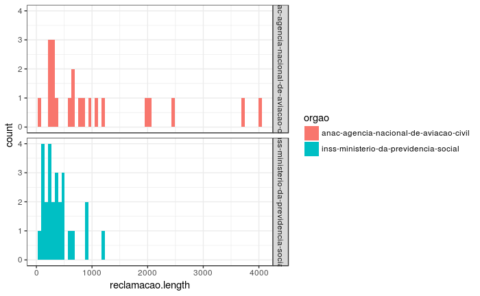

```r
avaliacoes_filtradas %>%
  ggplot(aes(fill = orgao, x = reclamacao.length), na.rm = TRUE) +
  geom_histogram(binwidth = 60, na.rm = TRUE) +
  facet_grid(orgao ~ .)
```

### Tamanho das reclamações em Boxplots

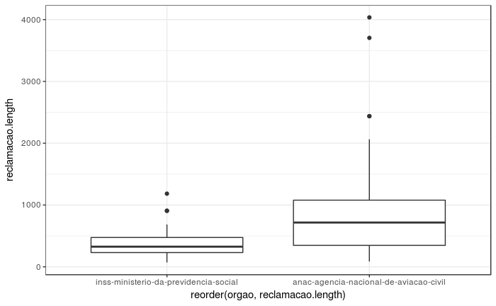

```r
reclamacoes %>% group_by(orgao) %>%
  ggplot(aes(x=reorder(orgao, reclamacao.length), y=reclamacao.length)) + geom_boxplot()
```

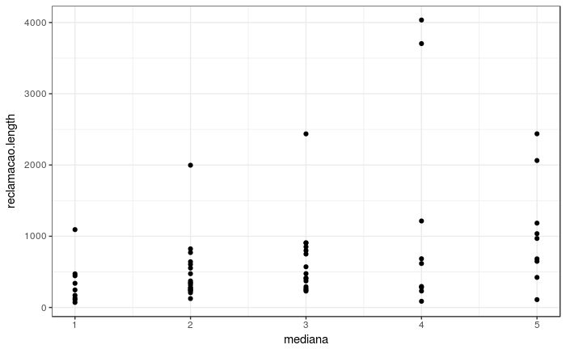

```r
## Será que os tamanhos das reclamações ou títulos tem alguma relação com o nível de insatisfação?
reclamacoes %>% ggplot(aes(x=mediana, y=reclamacao.length)) + geom_point()
```

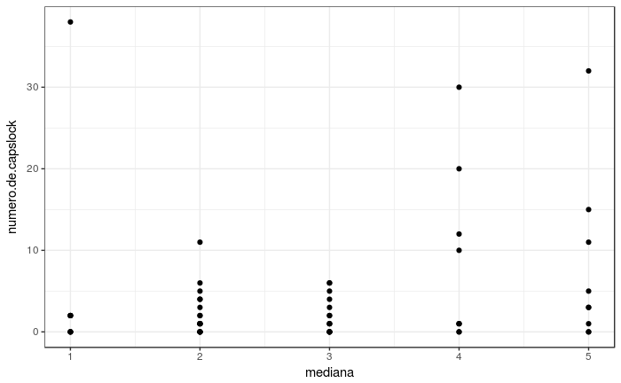

```r
reclamacoes %>% ggplot(aes(x=mediana, y=numero.de.capslock)) + geom_point()
```

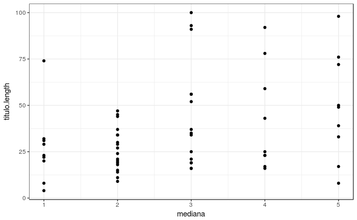

```r
reclamacoes %>% ggplot(aes(x=mediana, y=titulo.length)) + geom_point()
```

### Verificando relações entre as variáveis

Como podemos ver com os gráficos gerados abaixo, o coeficiente de correlação entre elas são baixos, assim, não encontramos relações fortes entre as variáveis.

[output not shown]

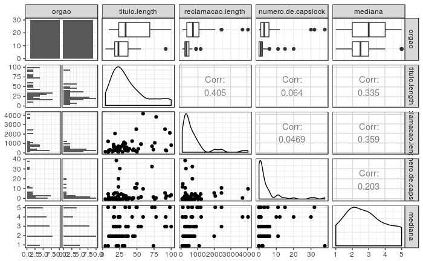

```r
# Olhando as variáveis não encontramos relações fortes entre elas
library(GGally)
reclamacoes %>%
  select(orgao, titulo.length, reclamacao.length, numero.de.capslock, mediana) %>%
  ggpairs()
```